# PCA and Clustering

Đặng Tuấn Vũ

Ngày 21 tháng 03 năm 2017

# 1 Giới thiệu.

**Unsupervised** là phương pháp để khám phá mối quan hệ của dữ liệu, với unsupervised chúng ta không biết biến phân loại (0-1) để dự báo, thay vào đó chúng ta sẽ đi tìm các mối quan hệ từ dữ liệu mà chúng ta chưa biết. Ví dụ, chúng ta đi tìm nhóm khách hàng có hành vi mua sắm tương tự nhau về loại hàng, số lượng hàng và tần suất mua hàng, từ đó chúng ta có thể xây dựng các mô hình dự báo. Unsupervised cũng là phương pháp để đánh giá tập dữ liệu ban đầu (phân nhóm, phân lớp để tạo các biến factor từ những biến liên lục ban đầu) trước khi chúng ta tiến hành các thủ tục trong các mô hình dự báo ở supervised (logit, decision tree,…)

Trong phân này chúng ta sẽ tập trung vào 2 vấn đề trong unsupervised:

- Phân tích thành phần chính (Principal component analysis - PCA)
- Phân lớp khách hàng (Clustering)

# 2 Phân tích thành phần chính (PCA)

- Phương pháp phân tích thành phần chính (Principal Component Analysis - PCA), đây là một phương pháp được sử dụng thường xuyên khi các nhà phân tích thống kê phải đối mặt với những bộ số liệu với số chiều lớn (big data). Vậy làm thể nào để giảm thiểu chiều dữ liệu mà vẫn không mất đi thông tin và giữ lại được những thông tin cần thiết cho việc xây dựng các mô hình thì mời mọi người theo dõi bài viết dưới đây để hiểu rõ hơn phương pháp của PCA cũng như việc ứng dụng R trong PCA đối với dữ liệu ngân hàng.
- Hình ảnh minh họa cho PCA:

Cùng là 1 chú lạc đà, tuy nhiên với các cách nhìn khác nhau (trục thông tin), chúng ta lại có những cách thu nhận thông tin khác nhau và cho ta những kết luận khác nhau.

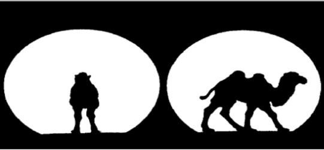

## 2.1 Đặc tính PCA

Một số đặc tính của PCA được kể đến như:

1. Giúp giảm số chiều dữ liệu - Giúp visualization khi dữ liệu có quá nhiều chiều thông tin.
2. Do dữ liệu ban đầu có số chiều lớn (nhiều biến) thì PCA giúp chúng ta xoay trục tọa độ xây một trục tọa độ mới đảm bảo độ biến thiên của dữ liệu và giữ lại được nhiều thông tin nhất mà không ảnh hưởng tới chất lượng của các mô hình dự báo. (Maximize the variability).
3. Do PCA giúp tạo 1 hệ trục tọa độ mới nên về mặt ý nghĩa toán học, PCA giúp chúng ta xây dựng những biến factor mới là tổ hợp tuyến tính của những biến ban đầu.
4. Trong không gian mới, có thẻ giúp chúng ta khám phá thêm những thông tin quý giá mới khi mà tại chiều thông tin cũ những thông tin quý giá này bị che mất (Điển hình cho ví dụ về chú lạc đà phía trên).

## 2.2 Mô hình PCA

- Xét tập không gian (dữ liệu) k biến, k biến này được biểu qua j thành phần chính sao cho (j < k). Xét thành phần chính đầu tiên có dạng:

$PC_{1} = a_{1}X_{1}+a_{2}X_{2}+...+a_{k}X_{k}$

## 2.3 Xác định số thành phần chính

- Lựa chọn số lượng thành phần chính dựa trên giá trị riêng (eigen value) thông qua ma trận hệ số tương quan, theo đề xuất **Kaiser - Harris** thành phần chính được xác định khi giá trị riêng lớn hơn 1. Dựa vào biểu đồ Cattel Scree.
- Lựa chọn số lượng thành phần chính dựa vào khả năng giải thích cho toàn bộ các biến ban đầu (thông thương tỷ lệ giải thích tích lũy trên 80%)

## 2.4 Các bước thực hiện phân tích PCA

```r
library(dplyr)
library(ggplot2)
library(psych)
library(factoextra)
```

- Sử dụng bộ dữ liệu **Harman 23** về các chỉ số về xương và cân nặng của 305 học sinh nữ độ tuổi từ 7 đến 17 tuổi

Bước 1: Dựa vào lược đồ Cattel Scree lựa chọn số thành phần chính.

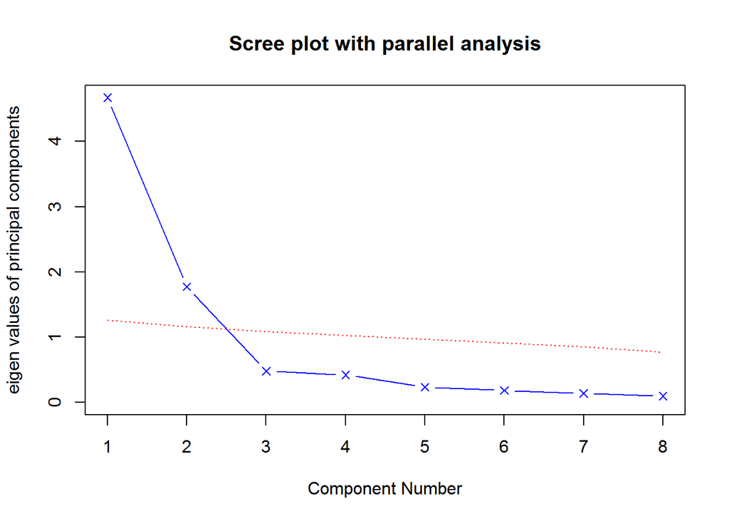

```
## Parallel analysis suggests that the number of factors =  NA  and the number of components =  2
```

```r
fa.parallel(Harman23.cor$cov, n.obs=302, fa="pc", n.iter=100,
            show.legend=FALSE, main="Scree plot with parallel analysis")
```

Bước 2: Thực hiện phân tích PCA với 2 thành phần chính.

```r
pc <- principal(Harman23.cor$cov, nfactors=2, rotate="none")

pc
```

```
## Principal Components Analysis
## Call: principal(r = Harman23.cor$cov, nfactors = 2, rotate = "none")
## Standardized loadings (pattern matrix) based upon correlation matrix
##                 PC1   PC2   h2    u2 com
## height         0.86 -0.37 0.88 0.123 1.4
## arm.span       0.84 -0.44 0.90 0.097 1.5
## forearm        0.81 -0.46 0.87 0.128 1.6
## lower.leg      0.84 -0.40 0.86 0.139 1.4
## weight         0.76  0.52 0.85 0.150 1.8
## bitro.diameter 0.67  0.53 0.74 0.261 1.9
## chest.girth    0.62  0.58 0.72 0.283 2.0
## chest.width    0.67  0.42 0.62 0.375 1.7
##
##                        PC1  PC2
## SS loadings           4.67 1.77
## Proportion Var        0.58 0.22
## Cumulative Var        0.58 0.81
## Proportion Explained  0.73 0.27
## Cumulative Proportion 0.73 1.00
##
## Mean item complexity =  1.7
## Test of the hypothesis that 2 components are sufficient.
##
## The root mean square of the residuals (RMSR) is  0.05
##
## Fit based upon off diagonal values = 0.99
```

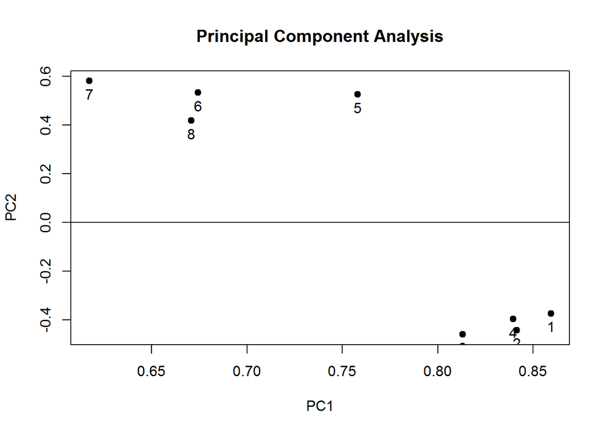

```r
plot(pc)
```

**Kết quả:** Chia làm 2 nhóm với 2 thành phần chính là nhóm những quan sát có những đặc tính về chiều dài và nhóm thiên về cân nặng.

## 2.5 Kết luận:

Ứng dụng PCA trong việc phân nhóm các đội tượng và ứng dụng trong hồi quy (PCA regression).

# 3 Kmean

## 3.1 Khái niệm

**K-Means** là thuật toán rất quan trọng và được sử dụng phổ biến trong kỹ thuật phân nhóm. Tư tưởng chính của thuật toán K-Means là tìm cách phân nhóm các đối tượng (objects) đã cho vào K nhóm (K là số các nhóm được xác đinh trước, K nguyên dương) sao cho tổng bình phương khoảng cách giữa các đối tượng đến tâm nhóm (centroid ) là nhỏ nhất.

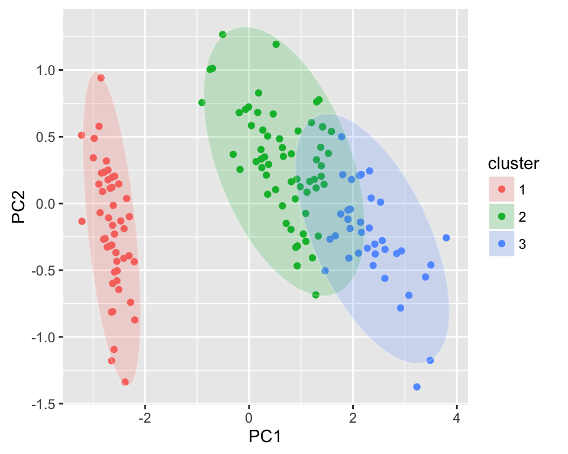

## 3.2 Thuật toán Kmean

**Các bước thực hiện thuật toán:**

- Bước 1: Chọn ngẫu nhiên K tâm ( tâm mỗi nhóm được xác định bằng trung bình của mỗi nhóm)
- Bước 2: Tính khoảng cách giữa các đối tượng quanh K tâm
- Bước 3: Nhóm các đối tượng vào nhóm gần nhất tạo thành K nhóm.
- Bước 4: Xác định lại tâm của K nhóm mới. (Bằng cách tính tâm K’ của các đội tượng trong cùng 1 nhóm)
- Bước 5: Thực hiện lại bước 2 cho đến K không tìm được sự thay đổi của các đối tượng trong các nhóm và giá trị WSS là nhỏ nhất

**Ý nghĩa của thuật toán:**

- Giảm thiểu sự khác biệt (phân tán giữa các điểm trong mỗi nhóm) - các điểm trong mỗi nhóm có mỗi quan hệ tương quan chặt chẽ với nhau về các thuộc tính xác định trước.
- Tối đa hóa sự phân tán giữa các nhóm (tâm các nhóm càng cách xa nhau càng tốt) - các điểm của mỗi nhóm khác biệt nhau nhiều nhất về các thuộc tính xác định trước.

**Điểm mạnh, điểm yêu thuật toán và cách khắc phục.**

- Điểm mạnh
  - Thuật toán đơn giản, dễ dàng tính toán
- Điểm yếu
  - Do lấy tâm ngẫu nhiên, nên khi chạy cùng 1 thuật toán có thể mỗi điểm lại được xác định ở mỗi nhóm khác nhau khi số biến input càng nhiều ==> các object càng nhạy.
  - Do các dữ liệu đầu vào có thang, cũng như đơn vị là khác nhau nên trọng số của mỗi chỉ tiêu là khác nhau.
- Cách khắc phục:
  - Chuẩn hóa dữ liệu đầu vào bằng cách:
  - Sử dụng hàm scale().
  - Chuẩn hóa dữ liệu đầu vào, công thức:

  $$x_{i}=\frac{x_{i}-min(x)}{max(x)- min(x)}$$

## 3.3 Các bước thực hiện thuật toán

- Bước 1: Tìm k nhóm tối ưu.

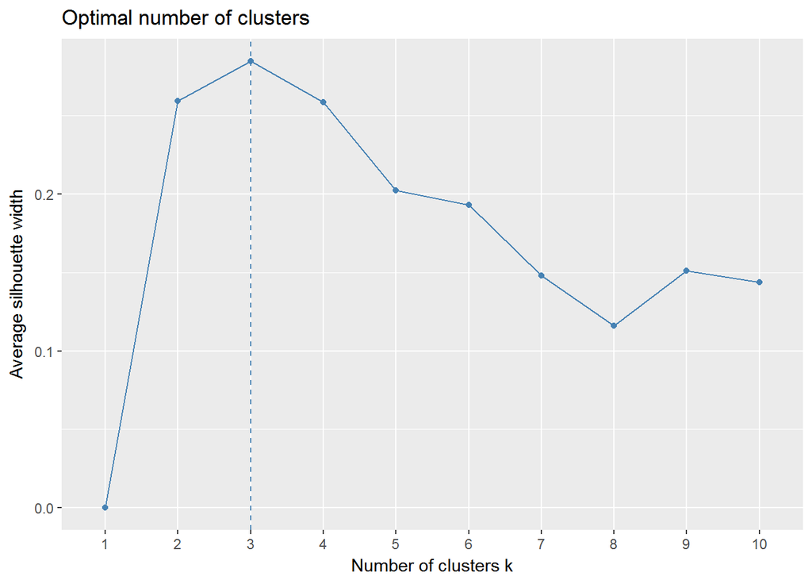

```
- Tùy vào mục đích mà muốn phân nhóm: có thể sử dụng 3 nhóm tối ưu, tuy nhiên với mục đích kinh doanh chúng ta cũng có thể chia thành nhiều nhóm khách nhau.
```

```r
data(wine, package='rattle')
wine.stand <- scale(wine[-1])
fviz_nbclust(wine.stand, kmeans, method = "silhouette")
```

- Bước 2: Thực hiện thuật toán Kmean với 3 nhóm tối ưu.

```r
k.means.fit <- kmeans(wine.stand, 3) # k = 3 (option)
attributes(k.means.fit)
```

```
## $names
## [1] "cluster"      "centers"      "totss"        "withinss"
## [5] "tot.withinss" "betweenss"    "size"         "iter"
## [9] "ifault"
##
## $class
## [1] "kmeans"
```

```
- Tâm mỗi nhóm:
```

```r
# Centroids:
round(k.means.fit$centers,2)
```

```
##   Alcohol Malic   Ash Alcalinity Magnesium Phenols Flavanoids
## 1   -0.92 -0.39 -0.49       0.17     -0.49   -0.08       0.02
## 2    0.16  0.87  0.19       0.52     -0.08   -0.98      -1.21
## 3    0.83 -0.30  0.36      -0.61      0.58    0.88       0.98
##   Nonflavanoids Proanthocyanins Color   Hue Dilution Proline
## 1         -0.03            0.06 -0.90  0.46     0.27   -0.75
## 2          0.72           -0.78  0.94 -1.16    -1.29   -0.41
## 3         -0.56            0.58  0.17  0.47     0.78    1.12
```

```
- Số đối tượng trong mỗi nhóm:
```

```r
# Size
k.means.fit$size
```

```
## [1] 65 51 62
```

```
- Các đối tượng ứng với các nhóm:
```

```r
# Clusters:
k.means.fit$cluster
```

```
##   [1] 3 3 3 3 3 3 3 3 3 3 3 3 3 3 3 3 3 3 3 3 3 3 3 3 3 3 3 3 3 3 3 3 3 3 3
##  [36] 3 3 3 3 3 3 3 3 3 3 3 3 3 3 3 3 3 3 3 3 3 3 3 3 1 1 2 1 1 1 1 1 1 1 1
##  [71] 1 1 1 3 1 1 1 1 1 1 1 1 1 2 1 1 1 1 1 1 1 1 1 1 1 3 1 1 1 1 1 1 1 1 1
## [106] 1 1 1 1 1 1 1 1 1 1 1 1 1 2 1 1 3 1 1 1 1 1 1 1 1 2 2 2 2 2 2 2 2 2 2
## [141] 2 2 2 2 2 2 2 2 2 2 2 2 2 2 2 2 2 2 2 2 2 2 2 2 2 2 2 2 2 2 2 2 2 2 2
## [176] 2 2 2
```

```
- Visualization các nhóm - ứng dụng PCA.
```

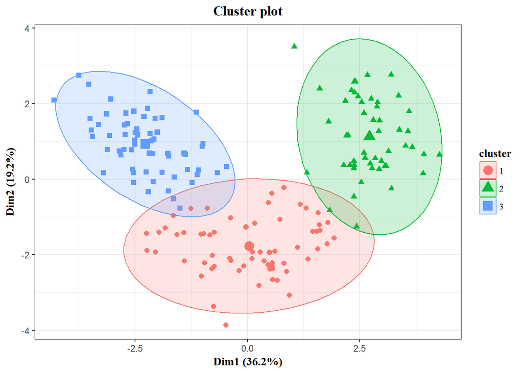

```r
fviz_cluster(k.means.fit,
             data = wine.stand,
             geom = "point",
             stand = FALSE, frame.type = "norm")+
  theme_bw()+
  theme(plot.title = element_text(hjust = 0.5),
        title = element_text(family = "serif",face = "bold"),
        legend.text = element_text(family = "serif"))
```

## 3.4 Kết luận

- Ứng dụng trong các bài toán phân lớp đặc biệt là tìm nhóm khách hàng để thúc đẩy MKT và cũng thể phân nhóm khách hàng làm các yếu tố đầu vào cho các bài toán supervised.

# 4 Hierachical clustering

## 4.1 Giới thiệu

Hình ảnh minh họa cho HC:

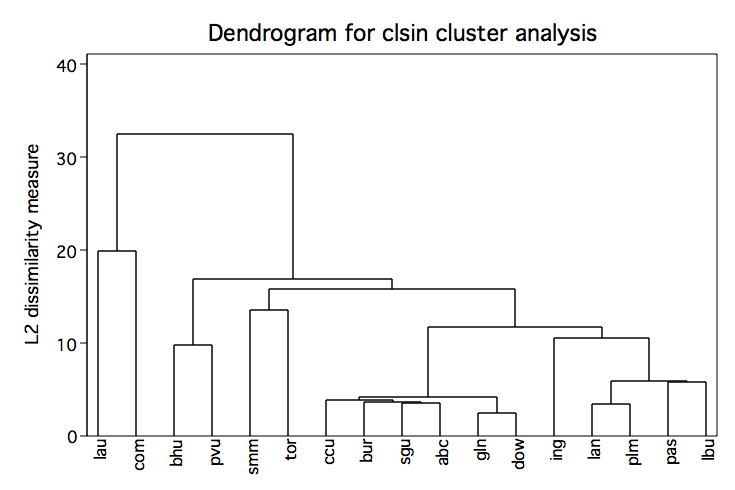

- Trong bài viết này chúng ta sẽ tiếp cận thuật toán này theo phương pháp **bottom up** nghĩa là: Phương pháp này thực hiện bằng cách, ban đầu xem mỗi đối tượng là 1 cluster, tiếp đó tính khoảng cách mỗi đối tượng và nhóm 2 đối tượng gần nhau nhất thành 1 cluster (Sử dụng khoảng cách Euclidean). Quá trính này lặp cho đến khi tất cả các đối tượng được nhóm vào 1 cluster.

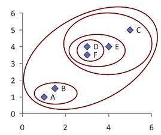

## 4.2 Thuật toán HC.

- Bước 1: Tính ma trận khoảng cách (Sử dụng khoảng cách Euclidean), nhóm 2 đối tượng có khoảng cách nhỏ nhất vào cùng 1 cluster.
- Bước 2: Tính khoảng cách cluster. Các cách tính liên kết giữa các đối tượng (Compute linkage between objects) sử dụng các độ đo. (option)

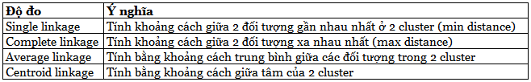

## 4.3 Các bước thực hiện thuật toán.

Bước 1: Tìm k nhóm tối ưu.

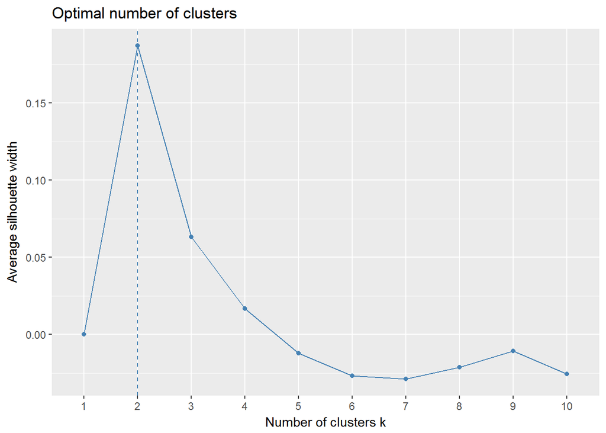

```r
fviz_nbclust(wine.stand[1:20,],
             hcut,
             method = "silhouette",
             hc_method = "centroid")
```

Bước 2: Thuật toán HC.

```r
distance <- dist(wine.stand[1:20,],
                 method = "euclidean"
                 ) ## Euclidean distance matrix.

H.fit <- hclust(distance, method="ward")
attributes(H.fit)
```

```
## $names
## [1] "merge"       "height"      "order"       "labels"      "method"
## [6] "call"        "dist.method"
##
## $class
## [1] "hclust"
```

Bước 3: Visualization các nhóm.

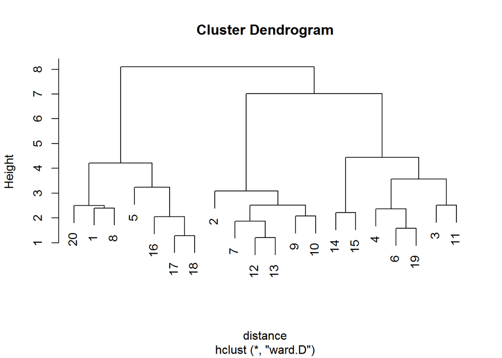

```r
plot(H.fit) # display dendogram (Kết quả phân nhóm các đối tượng)
```

## 4.4 Kết luận:

Chỉ phù hợp với việc phân nhóm khi ít các đối tượng ví dụ:

- Phân loại các trung tâm và chi nhánh.
- Phân loại case ATM.